[GitHub](https://github.com/agate-model/Agate.jl)[](https://github.com/agate-model/Agate.jl/blob/main/examples/reverse_mode_ad_onyx_sensitivity.jl)

# Reverse-mode AD sensitivity

This example differentiates the final total phytoplankton biomass in the default Onyx model with respect to several active parameters at once. The active parameter vector includes a scalar parameter, plankton-axis vector parameters, and predator-by-prey interaction matrix entries. We then differentiate the same objective with respect to two grazing traits that jointly determine the palatability matrix.

```julia
using Agate
using Onyx
using Agate.Construction: active_traits, realize_trait_parameters
using Agate.Library.Light: CyclicalPAR
using ADTypes: AutoEnzyme
using CairoMakie
import DifferentiationInterface
using Enzyme
using OrdinaryDiffEq: Tsit5, solve
using SciMLBase: remake, successful_retcode
using SciMLSensitivity

using Oceananigans.Biogeochemistry: required_biogeochemical_tracers
using Oceananigans.Units: day
```

## Static model and active parameter map

To run a model sensitivity analysis, we first choose the parameters that we want to vary: the active parameters.

Here we vary parameters controlling phytoplankton growth, detritus recycling, grazing preferences, and grazing efficiency. We then measure how changes in each parameter affect the final total phytoplankton biomass.

```julia
const RECIPE = last(Onyx.construct_plus_recipe(; scalar_type=Float64))
const TRAITS = active_traits(
    Onyx.OnyxFamily(),
    RECIPE;
    scalar_type=Float64,
    trait_selection=(specificity=(:Z_1,), optimum_predator_prey_ratio=(:Z_1,)),
)
const BGC = TRAITS.bgc
const TRACER_NAMES = Tuple(required_biogeochemical_tracers(BGC))
const PLANKTON_PFTS = Agate.Introspection.pfts(BGC)

function tracer_index(tracer::Symbol)
    index = findfirst(==(tracer), TRACER_NAMES)
    isnothing(index) && error("Tracer $tracer not found in $TRACER_NAMES")
    return index
end

const PHYTOPLANKTON = PLANKTON_PFTS.P
const PHYTOPLANKTON_INDICES = tracer_index.(PHYTOPLANKTON)

const ACTIVE = Agate.Runtime.active_parameters(
    BGC;
    maximum_growth_rate=(:P_1, :P_2),
    detritus_remineralization=true,
    palatability_matrix=((:Z_1, :P_1), (:Z_1, :P_2), (:Z_2, :P_1), (:Z_2, :P_2)),
    assimilation_matrix=((:Z_1, :P_1),),
)
const PARAMETER_LABELS = ACTIVE.labels

const θ_REFERENCE = copy(ACTIVE.values)

const SAVEAT = collect(range(0.0, 30day; length=31))
const TSPAN = (first(SAVEAT), last(SAVEAT))
const PAR = CyclicalPAR(-10)

const INITIAL_CONCENTRATIONS = (; N=7.0, D=0.01, Z_1=0.01, Z_2=0.01, P_1=0.01, P_2=0.1)

function initial_conditions(::Type{T}) where {T}
    return T[getproperty(INITIAL_CONCENTRATIONS, tracer) for tracer in TRACER_NAMES]
end

function onyx_problem(theta)
    T = eltype(theta)

    return Agate.Runtime.ode_problem(
        BGC,
        initial_conditions(T),
        TSPAN;
        p=theta,
        active_parameters=ACTIVE,
        auxiliary=(; PAR=t -> PAR(T(t))),
    )
end

const PROBLEM = onyx_problem(θ_REFERENCE)
```

## Endpoint objective

We measure sensitivity using the final total phytoplankton biomass after a short model run. The gradient tells us how strongly each active parameter affects that final biomass near the reference parameter values.

```julia
const SENSEALG = SciMLSensitivity.GaussAdjoint(; autojacvec=SciMLSensitivity.EnzymeVJP())

function solve_problem_values(
    problem;
    sensealg=nothing,
    saveat=SAVEAT,
    save_start=true,
    save_end=true,
    save_everystep=false,
    tol=1e-8,
)
    kwargs = (; abstol=tol, reltol=tol, saveat, save_start, save_end, save_everystep)

    if isnothing(sensealg)
        sol = solve(problem, Tsit5(); kwargs...)
        @assert successful_retcode(sol) "ODE solve failed: $(sol.retcode)"
        @assert last(sol.t) == TSPAN[end] "ODE did not reach the requested endpoint"
    else
        sol = solve(problem, Tsit5(); kwargs..., sensealg)
    end

    return Array(sol)
end

solve_values(theta; kwargs...) = solve_problem_values(remake(PROBLEM; p=theta); kwargs...)

function total_phytoplankton(values)
    total = zero(eltype(values))

    for i in PHYTOPLANKTON_INDICES
        total += values[i]
    end

    return total
end

function final_total_phytoplankton(theta; sensealg=nothing)
    values = solve_values(theta; sensealg, saveat=TSPAN[end], save_start=false)
    return total_phytoplankton(values[:, end])
end

function final_total_phytoplankton_adjoint(theta)
    return final_total_phytoplankton(theta; sensealg=SENSEALG)
end
```

## Enzyme gradient through DifferentiationInterface

DifferentiationInterface provides a common gradient API for several Julia AD backends. This example uses `AutoEnzyme`, which uses Enzyme.jl as the reverse-mode backend.

Parameters can have different units and magnitudes, so raw gradients are not always easy to compare. We rank sensitivities visually by `|θᵢ ∂J/∂θᵢ|`, which estimates how much each parameter contributes relative to its reference value.

```julia
const AD_BACKEND = AutoEnzyme(; mode=Enzyme.set_runtime_activity(Enzyme.Reverse))

function enzyme_gradient(theta)
    return DifferentiationInterface.gradient(
        final_total_phytoplankton_adjoint, AD_BACKEND, theta
    )
end

function diagnostic_plots(reference_values, scaled_sensitivities, order)
    days = SAVEAT ./ day

    trajectory_fig = Figure()
    ax = Axis(trajectory_fig[1, 1]; xlabel="Time (days)", ylabel="Total phytoplankton")
    phytoplankton = vec(sum(reference_values[PHYTOPLANKTON_INDICES, :]; dims=1))
    lines!(ax, days, phytoplankton)

    plot_order = reverse(order)

    sensitivity_fig = Figure(; size=(800, 400))
    ax = Axis(
        sensitivity_fig[1, 1];
        xlabel="|θᵢ ∂J/∂θᵢ|",
        yticks=(1:length(plot_order), collect(PARAMETER_LABELS)[plot_order]),
    )
    barplot!(ax, scaled_sensitivities[plot_order]; direction=:x)

    return (; trajectory=trajectory_fig, scaled_sensitivities=sensitivity_fig)
end

reference_values = solve_values(θ_REFERENCE)
gradient = enzyme_gradient(copy(θ_REFERENCE))
scaled_sensitivities = abs.(θ_REFERENCE .* gradient)
sensitivity_order = sortperm(scaled_sensitivities; rev=true)

plots = diagnostic_plots(reference_values, scaled_sensitivities, sensitivity_order)
```

```
(trajectory = Scene(1 children, 0 plots), scaled_sensitivities = Scene(1 children, 0 plots))
```

The reference trajectory shows the simulated total phytoplankton biomass used for the endpoint sensitivity calculation.

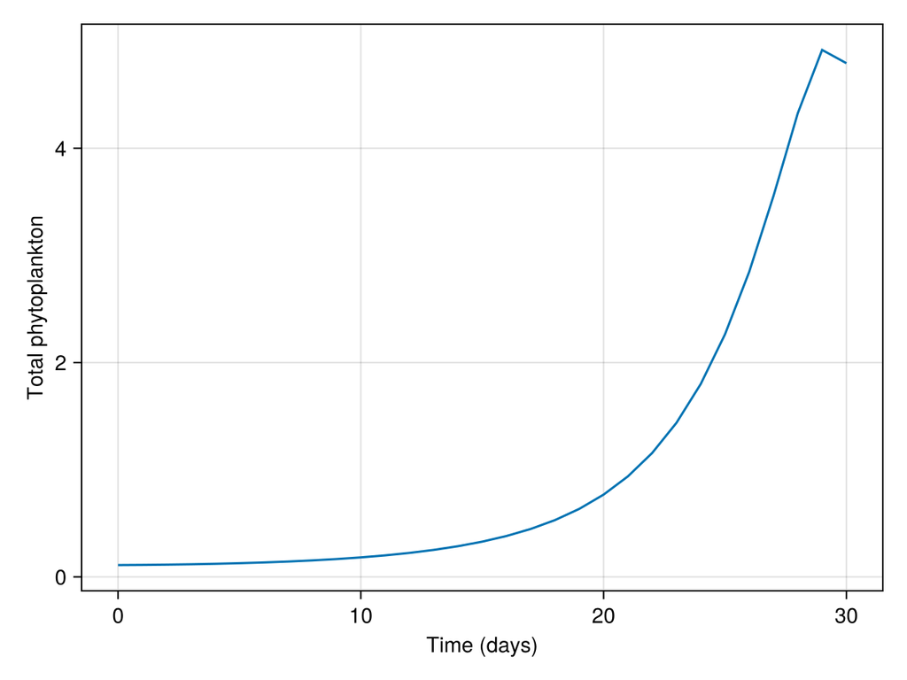

```julia
plots.trajectory
```

The scaled sensitivities rank active parameters by `|θᵢ ∂J/∂θᵢ|`.

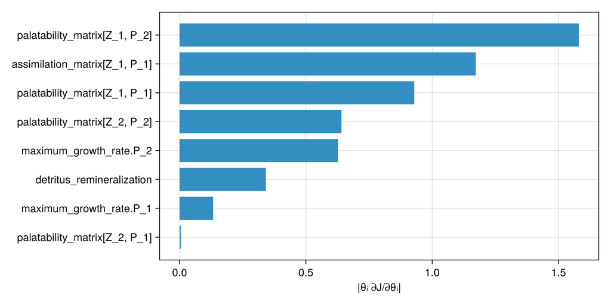

```julia
plots.scaled_sensitivities
```

## Construction-trait sensitivity

The predator's optimum predator-to-prey diameter ratio determines the location of its prey-size preference peak, while specificity controls how sharply preference declines away from that peak. Both traits influence the palatability matrix. The default ratio of 10 is a scientific model assumption that we can now perturb and differentiate.

`active_traits` identifies every applicable runtime entry influenced by the selected traits. We include those entries in the runtime parameter selection above, alongside the other independent parameters. This lets both sensitivity calculations use the same compiled ODE adjoint. Match the entries by label to preserve the trait map's ordering.

```julia
const τ_REFERENCE = copy(TRAITS.values)
const TRAIT_PARAMETER_INDICES = [
    only(findall(==(label), PARAMETER_LABELS)) for label in TRAITS.active_parameters.labels
]

function trait_runtime_parameters(tau)
    p = realize_trait_parameters(TRAITS, tau)
    theta = copy(θ_REFERENCE)
    theta[TRAIT_PARAMETER_INDICES] = p
    return theta
end

@assert trait_runtime_parameters(τ_REFERENCE) ≈ θ_REFERENCE
```

For a trait vector τ, the runtime parameters are p = f(τ). We apply the chain rule in two stages: first obtain the gradient of the endpoint objective with respect to the runtime parameters, then propagate those weights through the numerical trait map using Enzyme. The weights are recomputed at each trait vector and held constant during the pullback.

```julia
function weighted_trait_parameters(tau, parameter_map, weights)
    p = parameter_map(tau)
    total = zero(eltype(tau))
    for i in eachindex(p, weights)
        total += p[i] * weights[i]
    end
    return total
end

function trait_gradient(tau)
    theta = trait_runtime_parameters(tau)
    weights = enzyme_gradient(theta)[TRAIT_PARAMETER_INDICES]
    @assert all(isfinite, weights)
    g = zeros(eltype(tau), length(tau))
    Enzyme.autodiff(
        Enzyme.set_runtime_activity(Enzyme.Reverse),
        Enzyme.Const(weighted_trait_parameters),
        Enzyme.Active,
        Enzyme.Duplicated(copy(tau), g),
        Enzyme.Const(TRAITS.parameter_map),
        Enzyme.Const(weights),
    )
    return g
end
```

```
trait_gradient (generic function with 1 method)
```

### Verify the complete gradient

Independently reconstruct Onyx at each perturbed trait vector. Check that the resulting palatability matrix agrees entry by entry with the runtime mapping, then solve the ordinary model with the same initial conditions and light forcing. This verifies the entire trait-to-objective gradient, including dependencies realized during model construction.

```julia
function ordinary_trait_problem(tau)
    ordinary = Onyx.construct(;
        scalar_type=Float64,
        parameters=(specificity=(Z_1=tau[1],), optimum_predator_prey_ratio=(Z_1=tau[2],)),
    )
    @assert Tuple(required_biogeochemical_tracers(ordinary)) == TRACER_NAMES
    mapped = Agate.Runtime.parameterized(
        BGC, trait_runtime_parameters(tau); active_parameters=ACTIVE
    )
    matrix = ordinary.parameters.palatability_matrix
    @assert all(
        isapprox(
            matrix[i, j],
            mapped.parameters.palatability_matrix[i, j];
            rtol=1e-12,
            atol=1e-14,
        ) for i in axes(matrix, 1), j in axes(matrix, 2)
    )
    @assert all(
        name ->
            name === :palatability_matrix || isequal(
                getproperty(ordinary.parameters, name), getproperty(BGC.parameters, name)
            ),
        keys(BGC.parameters),
    )
    return Agate.Runtime.ode_problem(
        ordinary, initial_conditions(Float64), TSPAN; auxiliary=(; PAR=t -> PAR(Float64(t)))
    )
end

function ordinary_trait_endpoint(tau)
    values = solve_problem_values(
        ordinary_trait_problem(tau); saveat=TSPAN[end], save_start=false, tol=1e-10
    )
    return total_phytoplankton(values[:, end])
end

function finite_difference_trait_gradient(tau)
    return map(eachindex(tau)) do i
        h = 1e-3 * max(abs(tau[i]), 0.1)
        plus, minus = copy(tau), copy(tau)
        plus[i] += h
        minus[i] -= h
        return (ordinary_trait_endpoint(plus) - ordinary_trait_endpoint(minus)) / (2h)
    end
end

@assert isapprox(
    reference_values,
    solve_problem_values(ordinary_trait_problem(τ_REFERENCE));
    rtol=1e-6,
    atol=1e-8,
)
```

Verify the signed gradients at the default traits and at a second trait vector, then repeat the first gradient to check that the numerical mapping and derivative weights have no stale state.

```julia
τ_changed = 1.1 .* τ_REFERENCE
trait_gradients = map((τ_REFERENCE, τ_changed)) do tau
    endpoint = final_total_phytoplankton(trait_runtime_parameters(tau))
    @assert isfinite(endpoint)
    @assert isapprox(ordinary_trait_endpoint(tau), endpoint; rtol=1e-6, atol=1e-8)
    g = trait_gradient(tau)
    fd = finite_difference_trait_gradient(tau)
    @assert all(isfinite, g) "Nonfinite trait gradient at $tau: $g"
    @assert all(isapprox(a, b; rtol=1e-2, atol=1e-6) for (a, b) in zip(g, fd)) "Gradient mismatch at $tau: AD = $g, finite difference = $fd"
    return (; traits=copy(tau), gradient=g, finite_difference=fd, scaled=tau .* g)
end

reference_trait_gradient = first(trait_gradients).gradient
@assert all(abs.(reference_trait_gradient) .> 1e-5)
@assert isapprox(
    trait_gradient(τ_REFERENCE), reference_trait_gradient; rtol=1e-8, atol=1e-10
) "Reference gradient changed after updating traits"
@assert trait_runtime_parameters(τ_REFERENCE) ≈ θ_REFERENCE

for result in trait_gradients
    println("Trait values: ", result.traits)
    for (label, g, fd, scaled) in
        zip(TRAITS.labels, result.gradient, result.finite_difference, result.scaled)
        println(
            label,
            ": AD = ",
            g,
            ", finite difference = ",
            fd,
            ", scaled sensitivity = ",
            scaled,
        )
    end
end
```

```
Trait values: [0.3, 10.0]
specificity.Z_1: AD = 6.597146006562314, finite difference = 6.597157249859839, scaled sensitivity = 1.979143801968694
optimum_predator_prey_ratio.Z_1: AD = 0.11670547734262327, finite difference = 0.11670287000176138, scaled sensitivity = 1.1670547734262327
Trait values: [0.33, 11.0]
specificity.Z_1: AD = 3.5644181598568117, finite difference = 3.5644287117388447, scaled sensitivity = 1.176257992752748
optimum_predator_prey_ratio.Z_1: AD = 0.2234644160590918, finite difference = 0.22346223381377395, scaled sensitivity = 2.45810857665001
```

### Compare trait sensitivities

Signed scaled sensitivities, τᵢ ∂J/∂τᵢ, show how a small proportional increase in each trait changes the endpoint biomass near the reference configuration. The sign indicates whether that change increases or decreases the biomass. These local sensitivities can guide subsequent trait calibration or exploration of alternative prey-size preferences.

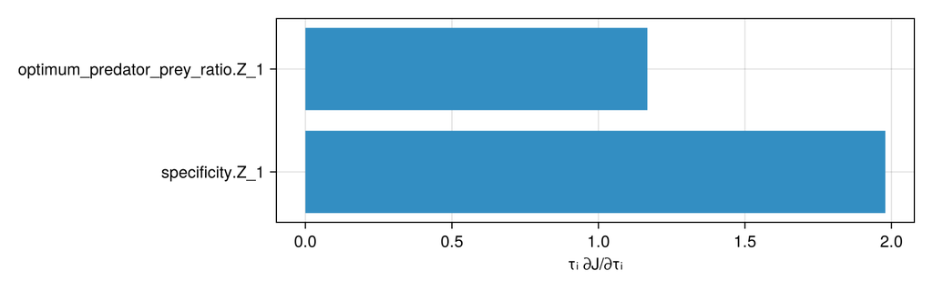

```julia
trait_fig = Figure(; size=(800, 250))
ax = Axis(
    trait_fig[1, 1];
    xlabel="τᵢ ∂J/∂τᵢ",
    yticks=(1:length(TRAITS.labels), collect(TRAITS.labels)),
)
barplot!(ax, first(trait_gradients).scaled; direction=:x)
trait_fig
```

*This page was generated using Literate.jl.*